# R Notebook - Case Study 2

```r
library(caret)
library(class)
df = read.csv("./data/casestudy2data.csv")
str(df)
```

```
'data.frame':   870 obs. of  36 variables:
 $ ID                      : int  1 2 3 4 5 6 7 8 9 10 ...
 $ Age                     : int  32 40 35 32 24 27 41 37 34 34 ...
 $ Attrition               : Factor w/ 2 levels "No","Yes": 1 1 1 1 1 1 1 1 1 1 ...
 $ BusinessTravel          : Factor w/ 3 levels "Non-Travel","Travel_Frequently",..: 3 3 2 3 2 2 3 3 3 2 ...
 $ DailyRate               : int  117 1308 200 801 567 294 1283 309 1333 653 ...
 $ Department              : Factor w/ 3 levels "Human Resources",..: 3 2 2 3 2 2 2 3 3 2 ...
 $ DistanceFromHome        : int  13 14 18 1 2 10 5 10 10 10 ...
 $ Education               : int  4 3 2 4 1 2 5 4 4 4 ...
 $ EducationField          : Factor w/ 6 levels "Human Resources",..: 2 4 2 3 6 2 4 2 2 6 ...
 $ EmployeeCount           : int  1 1 1 1 1 1 1 1 1 1 ...
 $ EmployeeNumber          : int  859 1128 1412 2016 1646 733 1448 1105 1055 1597 ...
 $ EnvironmentSatisfaction : int  2 3 3 3 1 4 2 4 3 4 ...
 $ Gender                  : Factor w/ 2 levels "Female","Male": 2 2 2 1 1 2 2 1 1 2 ...
 $ HourlyRate              : int  73 44 60 48 32 32 90 88 87 92 ...
```

[output cut: 22 more lines]

From the above output of the current dataset characteristics, we have 870 observations (rows of employees) and 36 variable. In efforts to predict employee turnover, we will utilize the `Attrition` factor as our response variable and the remaining variables as canidate predictor variables.

Next we explore to see if therea re missing values in the data set.

```r
sapply(df, function(x) sum(is.na(x)))
```

```
                      ID                      Age                Attrition           BusinessTravel                DailyRate               Department
                       0                        0                        0                        0                        0                        0
        DistanceFromHome                Education           EducationField            EmployeeCount           EmployeeNumber  EnvironmentSatisfaction
                       0                        0                        0                        0                        0                        0
                  Gender               HourlyRate           JobInvolvement                 JobLevel                  JobRole          JobSatisfaction
                       0                        0                        0                        0                        0                        0
           MaritalStatus            MonthlyIncome              MonthlyRate       NumCompaniesWorked                   Over18                 OverTime
                       0                        0                        0                        0                        0                        0
       PercentSalaryHike        PerformanceRating RelationshipSatisfaction            StandardHours         StockOptionLevel        TotalWorkingYears
                       0                        0                        0                        0                        0                        0
   TrainingTimesLastYear          WorkLifeBalance           YearsAtCompany       YearsInCurrentRole  YearsSinceLastPromotion     YearsWithCurrManager
                       0                        0                        0                        0                        0                        0
```

There does not appear to be any missing variables that we have to handel.

Next we do some exploration on the leangh of time employees spend at the company

```r
plot(df$YearsAtCompany);summary(df$YearsAtCompany)
```

[output not shown]

We will group the years into categories

```r
group_yr <- function(YearsAtCompany){
  if (YearsAtCompany >= 0 & YearsAtCompany <= 1){return('less_1_year')}
  else if(YearsAtCompany > 1 & YearsAtCompany <= 4){return('1-2_year')}
  else if (YearsAtCompany > 4 & YearsAtCompany <= 10){return('4-10_years')}
  else if (YearsAtCompany > 10 & YearsAtCompany <=20){return('10-20years')}
  else if (YearsAtCompany > 20){return('more_tha_20years')}
}
df$group_yr <- sapply(df$YearsAtCompany,group_yr)
df$group_yr <- as.factor(df$group_yr)
```

drop columns we dont need

```r
columns_to_drop = c("ID", "EmployeeNumber", "Over18", "StandardHours", "EmployeeCount" )
df = df[,!(names(df) %in% columns_to_drop)]
```

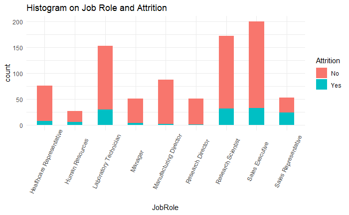

```r
library(ggplot2)
theme_set(theme_minimal())  # pre-set the bw theme.
# inspiration - http://r-statistics.co/Top50-Ggplot2-Visualizations-MasterList-R-Code.html
g <- ggplot(df, aes(JobRole))
g + geom_bar(aes(fill=Attrition), width = 0.5) +
  theme(axis.text.x = element_text(angle=65, vjust=0.6)) +
  labs(title="Histogram on Job Role and Attrition")
```

looks like we should do a log transformaiton

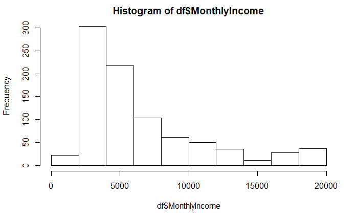

```r
hist(df$MonthlyIncome)
```

**log Trasformaitons**

```r
#attach(df)
df$Attrition <- factor(df$Attrition)
df$MonthlyIncome = log(df$MonthlyIncome)
```

```r
library(corrplot)
number_variables = sapply(df, is.numeric)
corrmatrix =  cor(df[,number_variables], )
```

```
the standard deviation is zero
```

[figure not shown]

```r
#top = colnames(corrmatrix)[apply(corrmatrix, 1, function (x) which(x==max(x[abs(x)>.9])))]
#corrmatrix =  cor(df[,top], )
corrplot(corrmatrix, method="color")
```

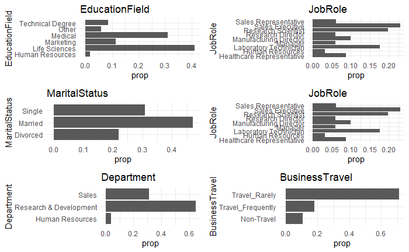

```r
library(gridExtra)
library(ggplot2)
# https://stackoverflow.com/questions/19835987/display-frequency-instead-of-count-with-geom-bar-in-ggplot
graph1= ggplot(df, aes(x=EducationField)) +
  geom_bar(aes(y = ..prop.., group=1)) +
  ggtitle("EducationField") +
  xlab("EducationField") +
  coord_flip()
graph2= ggplot(df, aes(x=JobRole)) +
  geom_bar(aes(y = ..prop.., group=1)) +
  ggtitle("JobRole") +
  xlab("JobRole") +
  coord_flip()
graph3 = ggplot(df, aes(x=MaritalStatus)) +
  geom_bar(aes(y = ..prop.., group=1)) +
  ggtitle("MaritalStatus") +
  xlab("MaritalStatus") +
  coord_flip()
graph4 = ggplot(df, aes(x=JobRole)) +
  geom_bar(aes(y = ..prop.., group=1)) +
  ggtitle("JobRole") +
  xlab("JobRole") +
  coord_flip()
graph5 = ggplot(df, aes(x=Department)) +
  geom_bar(aes(y = ..prop.., group=1)) +
  ggtitle("Department") +
  xlab("Department") +
  coord_flip()
graph6 = ggplot(df, aes(x=BusinessTravel)) +
  geom_bar(aes(y = ..prop.., group=1)) +
  ggtitle("BusinessTravel") +
  xlab("BusinessTravel") +
  coord_flip()
grid.arrange(graph1, graph2, graph3, graph4,
             graph5, graph6, ncol=2)
```

# Model Fitting

```r
stepwise = step(glm(Attrition ~ ., data=df, family = binomial(link="logit")), trace=0, direction='both',test="Chisq")
formula(stepwise)
```

```
Attrition ~ Age + BusinessTravel + DistanceFromHome + EnvironmentSatisfaction +
    HourlyRate + JobInvolvement + JobLevel + JobRole + JobSatisfaction +
    MaritalStatus + MonthlyIncome + NumCompaniesWorked + OverTime +
    RelationshipSatisfaction + TotalWorkingYears + TrainingTimesLastYear +
    WorkLifeBalance + YearsSinceLastPromotion + YearsWithCurrManager
```

```r
summary(stepwise)
```

```
Call:
glm(formula = Attrition ~ Age + BusinessTravel + DistanceFromHome +
    EnvironmentSatisfaction + HourlyRate + JobInvolvement + JobLevel +
    JobRole + JobSatisfaction + MaritalStatus + MonthlyIncome +
    NumCompaniesWorked + OverTime + RelationshipSatisfaction +
    TotalWorkingYears + TrainingTimesLastYear + WorkLifeBalance +
    YearsSinceLastPromotion + YearsWithCurrManager, family = binomial(link = "logit"),
    data = df)

Deviance Residuals:
    Min       1Q   Median       3Q      Max
-1.9562  -0.4661  -0.2161  -0.0689   3.3595

Coefficients:
                                 Estimate Std. Error z value Pr(>|z|)
(Intercept)                     11.255687   4.079504   2.759  0.00580 **
Age                             -0.033267   0.018009  -1.847  0.06471 .
BusinessTravelTravel_Frequently  1.588737   0.505585   3.142  0.00168 **
BusinessTravelTravel_Rarely      0.804037   0.446176   1.802  0.07154 .
DistanceFromHome                 0.306399   0.119373   2.567  0.01027 *
EnvironmentSatisfaction         -0.372816   0.113519  -3.284  0.00102 **
HourlyRate                       0.010189   0.006037   1.688  0.09143 .
JobInvolvement                  -0.827658   0.168334  -4.917 8.80e-07 ***
JobLevel                         0.697801   0.368199   1.895  0.05807 .
JobRoleHuman Resources           1.321377   0.795955   1.660  0.09689 .
JobRoleLaboratory Technician     0.673377   0.609953   1.104  0.26960
JobRoleManager                   0.325522   0.874850   0.372  0.70983
JobRoleManufacturing Director   -1.737356   0.881111  -1.972  0.04863 *
JobRoleResearch Director        -1.494353   1.245208  -1.200  0.23011
JobRoleResearch Scientist        0.084343   0.610790   0.138  0.89017
JobRoleSales Executive           0.646273   0.515748   1.253  0.21018
JobRoleSales Representative      1.588938   0.678443   2.342  0.01918 *
JobSatisfaction                 -0.480021   0.110805  -4.332 1.48e-05 ***
MaritalStatusMarried             0.940478   0.387582   2.427  0.01524 *
MaritalStatusSingle              1.846223   0.393800   4.688 2.76e-06 ***
MonthlyIncome                   -1.188070   0.505052  -2.352  0.01865 *
NumCompaniesWorked               0.235807   0.051709   4.560 5.11e-06 ***
OverTimeYes                      2.005098   0.257641   7.783 7.11e-15 ***
RelationshipSatisfaction        -0.256644   0.106963  -2.399  0.01642 *
TotalWorkingYears               -0.084763   0.037840  -2.240  0.02509 *
TrainingTimesLastYear           -0.279446   0.101777  -2.746  0.00604 **
WorkLifeBalance                 -0.586322   0.166523  -3.521  0.00043 ***
YearsSinceLastPromotion          0.265876   0.053551   4.965 6.87e-07 ***
YearsWithCurrManager            -0.153841   0.053275  -2.888  0.00388 **
---
Signif. codes:  0 ‘***’ 0.001 ‘**’ 0.01 ‘*’ 0.05 ‘.’ 0.1 ‘ ’ 1

(Dispersion parameter for binomial family taken to be 1)

    Null deviance: 767.67  on 869  degrees of freedom
Residual deviance: 478.04  on 841  degrees of freedom
AIC: 536.04

Number of Fisher Scoring iterations: 7
```

**test train split**

```r
smp_size <- floor(0.7 * nrow(df))
## set the seed to make your partition reproducible
set.seed(123)
train_ind <- sample(seq_len(nrow(df)), size = smp_size)
train = df[train_ind,]
test =  df[-train_ind,]
dim(train)
```

```
[1] 609  31
```

```r
dim(test)
```

```
[1] 261  31
```

### Logistic Model

```r
library(class)
#library(caret)
logit_model <- glm(formula(stepwise),
                   family=binomial(link="logit"),data=train)
logit_pred = predict(logit_model, newdata=test, type='response')
logit_pred = ifelse(logit_pred > 0.85 ,1,0)
error_ = mean(logit_pred != test$Attrition)
print(summary(logit_model))
```

```
Call:
glm(formula = formula(stepwise), family = binomial(link = "logit"),
    data = train)

Deviance Residuals:
    Min       1Q   Median       3Q      Max
-1.7461  -0.4588  -0.2390  -0.0626   3.1755

Coefficients:
                                  Estimate Std. Error z value Pr(>|z|)
(Intercept)                      1.066e+01  4.847e+00   2.200 0.027828 *
Age                             -2.469e-02  2.074e-02  -1.191 0.233793
BusinessTravelTravel_Frequently  1.338e+00  5.878e-01   2.276 0.022859 *
BusinessTravelTravel_Rarely      6.709e-01  5.180e-01   1.295 0.195251
DistanceFromHome                 3.522e-01  1.463e-01   2.408 0.016020 *
EnvironmentSatisfaction         -3.008e-01  1.371e-01  -2.194 0.028261 *
HourlyRate                       1.002e-02  7.168e-03   1.399 0.161925
JobInvolvement                  -7.198e-01  2.099e-01  -3.430 0.000604 ***
JobLevel                         2.429e-04  4.549e-01   0.001 0.999574
JobRoleHuman Resources           5.771e-01  1.005e+00   0.574 0.565746
JobRoleLaboratory Technician     4.132e-01  7.508e-01   0.550 0.582079
JobRoleManager                   1.625e+00  1.035e+00   1.570 0.116393
JobRoleManufacturing Director   -1.015e+00  9.848e-01  -1.031 0.302503
JobRoleResearch Director        -1.519e+01  8.947e+02  -0.017 0.986454
JobRoleResearch Scientist       -2.318e-01  7.551e-01  -0.307 0.758870
JobRoleSales Executive           5.505e-01  6.543e-01   0.841 0.400138
JobRoleSales Representative      1.119e+00  8.183e-01   1.368 0.171382
JobSatisfaction                 -4.435e-01  1.363e-01  -3.254 0.001138 **
MaritalStatusMarried             1.320e+00  5.081e-01   2.598 0.009386 **
MaritalStatusSingle              2.053e+00  5.136e-01   3.997 6.41e-05 ***
MonthlyIncome                   -1.216e+00  5.939e-01  -2.048 0.040548 *
NumCompaniesWorked               1.971e-01  6.365e-02   3.097 0.001954 **
OverTimeYes                      2.069e+00  3.071e-01   6.738 1.61e-11 ***
RelationshipSatisfaction        -2.012e-01  1.274e-01  -1.579 0.114349
TotalWorkingYears               -3.891e-02  4.533e-02  -0.858 0.390685
TrainingTimesLastYear           -3.207e-01  1.176e-01  -2.727 0.006386 **
WorkLifeBalance                 -3.080e-01  2.039e-01  -1.511 0.130910
YearsSinceLastPromotion          1.784e-01  6.889e-02   2.589 0.009621 **
YearsWithCurrManager            -1.124e-01  6.576e-02  -1.709 0.087359 .
---
Signif. codes:  0 ‘***’ 0.001 ‘**’ 0.01 ‘*’ 0.05 ‘.’ 0.1 ‘ ’ 1

(Dispersion parameter for binomial family taken to be 1)

    Null deviance: 517.11  on 608  degrees of freedom
Residual deviance: 331.82  on 580  degrees of freedom
AIC: 389.82

Number of Fisher Scoring iterations: 17
```

```r
print(1-error_)
```

```
[1] 0.8314176
```

```r
cm = table(test$Attrition,logit_pred)
print(cm)
```

```
   logit_pred
      0   1
  0 213   0
  1  44   4
```

```r
tn = cm[1]
fn = cm[2]
fp = cm[3]
tp = cm[4]
sensitivity = tp / (tp + fn)
specificity = tn / (tn + fp)
accuracy = (tp + tn) / (tp + tn + fp + fn)
misclassification_rate = 1 - accuracy
print(paste("sensitivity: ", sensitivity))
```

```
[1] "sensitivity:  0.0833333333333333"
```

```r
print(paste("specificity: ", specificity))
```

```
[1] "specificity:  1"
```

```r
#logit_model_null <- glm(Attrition~ 1,family=binomial(link="logit"),data=train)
anova(logit_model,  test="Chisq")
```

```
Analysis of Deviance Table

Model: binomial, link: logit

Response: Attrition

Terms added sequentially (first to last)

                         Df Deviance Resid. Df Resid. Dev  Pr(>Chi)
NULL                                       608     517.11
Age                       1   16.485       607     500.62 4.903e-05 ***
BusinessTravel            2    2.513       605     498.11  0.284712
DistanceFromHome          1    1.905       604     496.21  0.167474
EnvironmentSatisfaction   1    2.107       603     494.10  0.146626
HourlyRate                1    1.534       602     492.57  0.215565
JobInvolvement            1   15.486       601     477.08 8.312e-05 ***
JobLevel                  1   16.547       600     460.53 4.746e-05 ***
JobRole                   8   18.087       592     442.45  0.020585 *
JobSatisfaction           1    7.435       591     435.01  0.006397 **
MaritalStatus             2   19.085       589     415.93 7.173e-05 ***
MonthlyIncome             1    4.057       588     411.87  0.043982 *
NumCompaniesWorked        1    7.304       587     404.56  0.006879 **
OverTime                  1   52.970       586     351.59 3.386e-13 ***
RelationshipSatisfaction  1    2.803       585     348.79  0.094094 .
TotalWorkingYears         1    0.568       584     348.22  0.450961
TrainingTimesLastYear     1    7.445       583     340.78  0.006361 **
WorkLifeBalance           1    1.670       582     339.11  0.196240
YearsSinceLastPromotion   1    4.259       581     334.85  0.039036 *
YearsWithCurrManager      1    3.023       580     331.82  0.082086 .
---
Signif. codes:  0 ‘***’ 0.001 ‘**’ 0.01 ‘*’ 0.05 ‘.’ 0.1 ‘ ’ 1
```

```r
logit_model <- glm(Attrition ~ OverTime+MonthlyIncome + MaritalStatus + JobInvolvement+JobRole ,
                   family=binomial(link="logit"),data=train)
logit_pred = predict(logit_model, newdata=test, type='response')
logit_pred = ifelse(logit_pred > 0.5 ,1,0)
print(summary(logit_model))
```

```
Call:
glm(formula = Attrition ~ OverTime + MonthlyIncome + MaritalStatus +
    JobInvolvement + JobRole, family = binomial(link = "logit"),
    data = train)

Deviance Residuals:
    Min       1Q   Median       3Q      Max
-1.7292  -0.5240  -0.3222  -0.1273   2.8045

Coefficients:
                               Estimate Std. Error z value Pr(>|z|)
(Intercept)                     8.78374    3.65452   2.404 0.016238 *
OverTimeYes                     1.89093    0.27193   6.954 3.56e-12 ***
MonthlyIncome                  -1.34718    0.40551  -3.322 0.000893 ***
MaritalStatusMarried            1.42309    0.48905   2.910 0.003616 **
MaritalStatusSingle             1.82596    0.49134   3.716 0.000202 ***
JobInvolvement                 -0.55672    0.18596  -2.994 0.002755 **
JobRoleHuman Resources          0.33867    0.88777   0.381 0.702843
JobRoleLaboratory Technician   -0.03698    0.65528  -0.056 0.954999
JobRoleManager                  1.38778    0.86231   1.609 0.107536
JobRoleManufacturing Director  -0.84400    0.90418  -0.933 0.350592
JobRoleResearch Director      -14.09427  582.28701  -0.024 0.980689
JobRoleResearch Scientist      -0.31556    0.65281  -0.483 0.628818
JobRoleSales Executive          0.40743    0.57849   0.704 0.481248
JobRoleSales Representative     0.76602    0.71632   1.069 0.284895
---
Signif. codes:  0 ‘***’ 0.001 ‘**’ 0.01 ‘*’ 0.05 ‘.’ 0.1 ‘ ’ 1

(Dispersion parameter for binomial family taken to be 1)

    Null deviance: 517.11  on 608  degrees of freedom
Residual deviance: 381.31  on 595  degrees of freedom
AIC: 409.31

Number of Fisher Scoring iterations: 16
```

```r
cm = table(logit_pred,test$Attrition)
print(cm)
```

```
logit_pred   0   1
         0 210  34
         1   3  14
```

```r
tn = cm[1]
fn = cm[2]
fp = cm[3]
tp = cm[4]
sensitivity = tp / (tp + fn)
specificity = tn / (tn + fp)
accuracy = (tp + tn) / (tp + tn + fp + fn)
misclassification_rate = 1 - accuracy
print(paste("sensitivity: ", round(sensitivity,2)))
```

```
[1] "sensitivity:  0.82"
```

```r
print(paste("specificity: ", round(specificity,2)))
```

```
[1] "specificity:  0.86"
```

```r
print(paste("accuracy: ", round(accuracy,2)))
```

```
[1] "accuracy:  0.86"
```

```r
anova(logit_model,  test="Chisq")
```

```
Analysis of Deviance Table

Model: binomial, link: logit

Response: Attrition

Terms added sequentially (first to last)

               Df Deviance Resid. Df Resid. Dev  Pr(>Chi)
NULL                             608     517.11
OverTime        1   48.641       607     468.47 3.074e-12 ***
MonthlyIncome   1   40.092       606     428.38 2.423e-10 ***
MaritalStatus   2   21.637       604     406.74 2.002e-05 ***
JobInvolvement  1    9.511       603     397.23  0.002042 **
JobRole         8   15.913       595     381.31  0.043642 *
---
Signif. codes:  0 ‘***’ 0.001 ‘**’ 0.01 ‘*’ 0.05 ‘.’ 0.1 ‘ ’ 1
```

[output not shown]

reviewing the coeficiencts output - all execpt JobRole are significant.

the updated logistic regression model provided the following: - Sensitivity = 82% - specificity = 86% - Missclassificaiton rate = 14%

```r
submission_  = read.csv("./data/CaseStudy2CompSet No Attrition.csv")
submission_pred = predict(logit_model, newdata=submission_, type='response')
submission_pred = ifelse(submission_pred > 0.5 ,"Yes","No")
final_submission = data.table(ID=submission_$ID, Attrition=submission_pred)
write.table(final_submission, "./data/Attrition_submission_phillip.csv", sep=",", row.names=F)
```

## Random Forest

```r
library(randomForest)
#rf = randomForest(formula(stepwise), data = train,proximity=TRUE,mtry=2, importance=TRUE )
rf = randomForest(Attrition ~ OverTime+MonthlyIncome  +JobLevel+ MaritalStatus + TotalWorkingYears +StockOptionLevel + YearsWithCurrManager+YearsAtCompany + Age
                  , data = train,proximity=TRUE,mtry=2, importance=TRUE )
```

```
The response has five or fewer unique values.  Are you sure you want to do regression?
```

```r
print(rf)
```

```
Call:
 randomForest(formula = Attrition ~ OverTime + MonthlyIncome +      JobLevel + MaritalStatus + TotalWorkingYears + StockOptionLevel +      YearsWithCurrManager + YearsAtCompany + Age, data = train,      proximity = TRUE, mtry = 2, importance = TRUE)
               Type of random forest: regression
                     Number of trees: 500
No. of variables tried at each split: 2

          Mean of squared residuals: 0.1115264
                    % Var explained: 13.04
```

```r
rf_pred = predict(rf,newdata=test, type="class")
rf_pred = ifelse(rf_pred > 0.5,1,0)
cm = table(rf_pred, test$Attrition)
print(mean(rf_pred==test$Attrition))
```

```
[1] 0.8505747
```

```r
print(cm)
```

```
rf_pred   0   1
      0 211  37
      1   2  11
```

```r
tn = cm[1]
fn = cm[2]
fp = cm[3]
tp = cm[4]
sensitivity = tp / (tp + fn)
specificity = tn / (tn + fp)
accuracy = (tp + tn) / (tp + tn + fp + fn)
misclassification_rate = 1 - accuracy
print(paste("sensitivity: ", round(sensitivity,2)))
```

```
[1] "sensitivity:  0.85"
```

```r
print(paste("specificity: ", round(specificity,2)))
```

```
[1] "specificity:  0.85"
```

```r
print(paste("accuracy: ", round(accuracy,2)))
```

```
[1] "accuracy:  0.85"
```

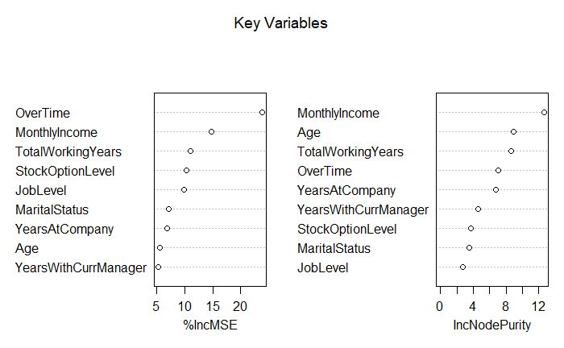

```r
#confusionMatrix(rf_pred, test_Attrition)
varImpPlot(rf, sort=T, n.var = 9, main = 'Key Variables')
```

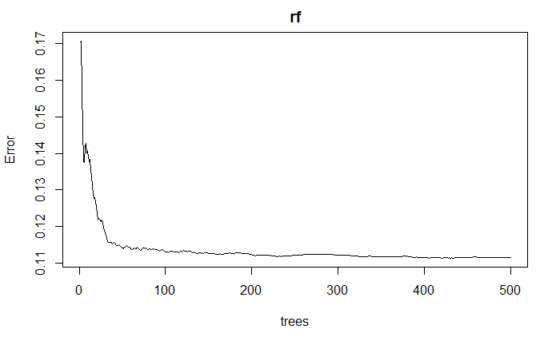

```r
plot(rf)
```

```r
# https://www.r-bloggers.com/variable-importance-plot-and-variable-selection/
(VI_F=importance(rf))
```

```
                       %IncMSE IncNodePurity
OverTime             23.836162      7.099323
MonthlyIncome        14.787891     12.682604
JobLevel              9.923178      2.747512
MaritalStatus         7.159041      3.495974
TotalWorkingYears    11.054809      8.653446
StockOptionLevel     10.248559      3.745384
YearsWithCurrManager  5.331003      4.606315
YearsAtCompany        6.835828      6.757518
Age                   5.559646      8.882013
```

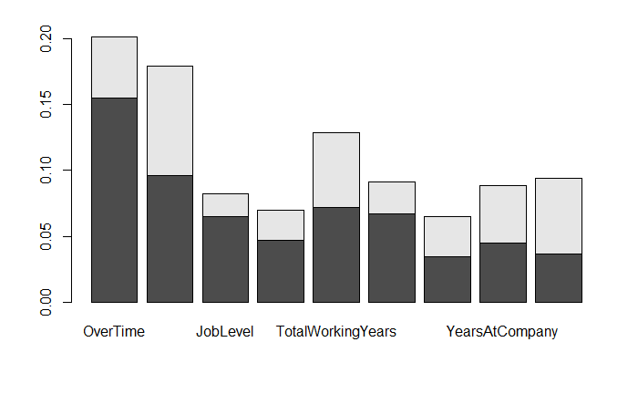

```r
barplot(t(VI_F/sum(VI_F)))
```

### KNN

```r
sepwise_variables = c("Attrition","Age","DistanceFromHome","JobInvolvement","JobLevel","JobSatisfaction",
    "MonthlyIncome","TotalWorkingYears","TrainingTimesLastYear",
    "WorkLifeBalance","YearsSinceLastPromotion","YearsWithCurrManager", "JobRole")
numerica_var = c("Attrition","Age","DistanceFromHome","JobInvolvement","JobLevel","JobSatisfaction",
    "MonthlyIncome","TotalWorkingYears","TrainingTimesLastYear",
    "WorkLifeBalance","YearsSinceLastPromotion","YearsWithCurrManager")
categorical_var = c("JobRole")
knn_df = df[,sepwise_variables]
knn_df = fastDummies::dummy_cols(knn_df, select_columns=categorical_var, remove_first_dummy=TRUE)
knn_df = knn_df[,!(names(knn_df) %in% categorical_var)]
colnames(knn_df)[which(colnames(knn_df) %in% c("JobRole_Manufacturing Director","JobRole_Research Director",
                                               "JobRole_Research Scientist","JobRole_Sales Representative",
                                               "JobRole_Healthcare Representative","JobRole_Human Resources",
                                               "JobRole_Laboratory Technician") )] <- c("role_manf_direc","role_director",
                                                            "role_science", "rolesales_rep", "role_healthrep",
                                                            "role_HR", "role_lab"
                                                                                                                )
knn_df$travel_freq = ifelse(df$BusinessTravel == "Travel_Frequently", 1, 0)
knn_df$male = ifelse(df$Gender == "Male", 1, 0)
knn_df$OT = ifelse(df$OverTime == "Yes", 1, 0)
paste(names(knn_df), collapse = " + ")
```

[output not shown]

_**test train**

```r
smp_size <- floor(0.7 * nrow(knn_df))
## set the seed to make your partition reproducible
set.seed(234)
train_ind <- sample(seq_len(nrow(knn_df)), size = smp_size, replace=FALSE)
train = knn_df[train_ind,]
test =  knn_df[-train_ind,]
dim(train)
```

```
[1] 609  23
```

```r
dim(test)
```

```
[1] 261  23
```

```r
k3 = knn(train,test,cl=train$Attrition,k=20)
confusionMatrix(table(test$Attrition,k3))
```

```
Confusion Matrix and Statistics

   k3
      0   1
  0 213   1
  1  45   2

               Accuracy : 0.8238
                 95% CI : (0.772, 0.868)
    No Information Rate : 0.9885
    P-Value [Acc > NIR] : 1

                  Kappa : 0.0597

 Mcnemar's Test P-Value : 2.298e-10

            Sensitivity : 0.82558
            Specificity : 0.66667
         Pos Pred Value : 0.99533
         Neg Pred Value : 0.04255
             Prevalence : 0.98851
         Detection Rate : 0.81609
   Detection Prevalence : 0.81992
      Balanced Accuracy : 0.74612

       'Positive' Class : 0
```

From the KNN we obtained an accuracy rating of 82% on the test dataset. The Sensitivy = 82% and the specificity = 66%. With the objective of predicting employees that left the company, the KNN model indicates the specificity rate is 67% which is appropriate.

```r
library(e1071)
nb = naiveBayes(Attrition ~ OverTime+MonthlyIncome  +JobLevel+ MaritalStatus + TotalWorkingYears +StockOptionLevel + YearsWithCurrManager+YearsAtCompany + Age, data=train)
nb_pred = predict(nb, newdata=test)
#nb_pred = ifelse(nb_pred > 0.5,1,0)
#table(nb_pred, test$Attrition)
```

```r
stepwise = step(glm(MonthlyIncome ~ ., data=df), direction='both', trace=0)
formula(stepwise)
```

[output not shown]

```r
summary(stepwise)
```

[output not shown]

```r
df$freq_travel <- ifelse(df$BusinessTravel == "Travel_Frequently", 1, 0)
```

_**test train**

```r
df$TotalWorkingYears_log = log(df$TotalWorkingYears_log+0.5)
smp_size <- floor(0.7 * nrow(df))
## set the seed to make your partition reproducible
set.seed(123)
train_ind <- sample(seq_len(nrow(df)), size = smp_size)
train = df[train_ind,]
test =  df[-train_ind,]
dim(train)
```

```
[1] 609  32
```

```r
dim(test)
```

```
[1] 261  32
```

```r
lm_model <- lm(MonthlyIncome ~ JobLevel+JobRole+Attrition + TotalWorkingYears_log, data=train)
print(summary(lm_model))
```

```
Call:
lm(formula = MonthlyIncome ~ JobLevel + JobRole + Attrition +
    TotalWorkingYears_log, data = train)

Residuals:
     Min       1Q   Median       3Q      Max
-0.77936 -0.13293 -0.00155  0.13703  0.61615

Coefficients:
                               Estimate Std. Error t value Pr(>|t|)
(Intercept)                    7.577305   0.053556 141.485  < 2e-16 ***
JobLevel                       0.353825   0.016923  20.908  < 2e-16 ***
JobRoleHuman Resources        -0.204909   0.062640  -3.271  0.00113 **
JobRoleLaboratory Technician  -0.334687   0.039006  -8.580  < 2e-16 ***
JobRoleManager                 0.158123   0.052990   2.984  0.00296 **
JobRoleManufacturing Director  0.031539   0.040491   0.779  0.43634
JobRoleResearch Director       0.244295   0.050092   4.877 1.38e-06 ***
JobRoleResearch Scientist     -0.285954   0.039433  -7.252 1.28e-12 ***
JobRoleSales Executive        -0.009086   0.033748  -0.269  0.78785
JobRoleSales Representative   -0.320684   0.048613  -6.597 9.28e-11 ***
Attrition                     -0.026610   0.025337  -1.050  0.29403
TotalWorkingYears_log          0.369201   0.033663  10.967  < 2e-16 ***
---
Signif. codes:  0 ‘***’ 0.001 ‘**’ 0.01 ‘*’ 0.05 ‘.’ 0.1 ‘ ’ 1

Residual standard error: 0.212 on 597 degrees of freedom
Multiple R-squared:  0.9016,    Adjusted R-squared:  0.8998
F-statistic: 497.2 on 11 and 597 DF,  p-value: < 2.2e-16
```

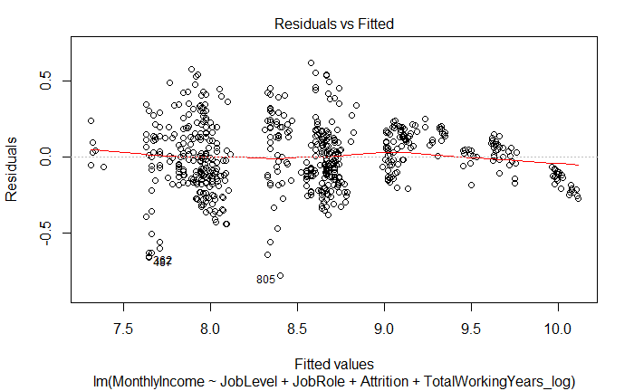

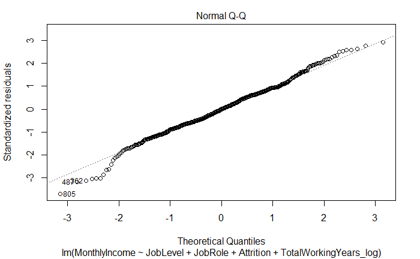

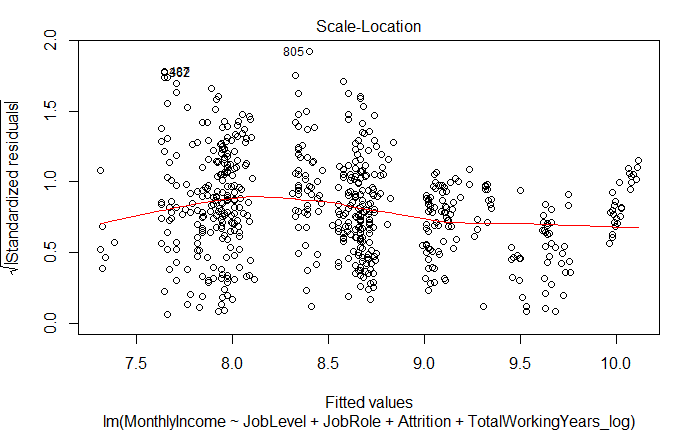

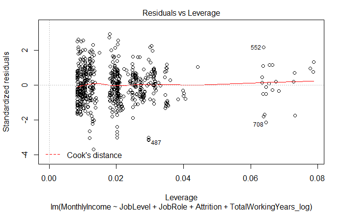

```r
plot(lm_model)
```

```r
library(tidyverse)
# http://www.sthda.com/english/articles/38-regression-model-validation/158-regression-model-accuracy-metrics-r-square-aic-bic-cp-and-more/
lm_pred <- exp(predict(lm_model, test))
score = data.frame(
  AdjR2 = (summary(lm_model)$adj.r.squared),
  RMSE = RMSE(lm_pred, exp(test$MonthlyIncome)),
  AIC =  (extractAIC(lm_model))
)
score
```

| AdjR2 | RMSE | AIC |
| --- | --- | --- |
| 0.8997785 | 1311.868 | 12.000 |
| 0.8997785 | 1311.868 | -1877.501 |

To assess the assumptions being met, we considered the following that is presinted above in the diagnostic plots: * Normality - QQ plots show the residual fitting well on linear line, some small deviations from the lower tail, but nothing to be conserned. assumption met * Independence - the data discription did not present any concerns that the data fails independence - assumption met * equal variance - after the log transformaiton on `TotalWorkingYears` provided better output in the residual v fits plot that provides indicate of equal variance. Additionally, in the leverage plot, there are no significant concerns regarding leverage and influence that could violate this assumption. While we note the leverage plot call out potential outlier, this appears to be no significant concern - assumption ment

R-squared is approximately 90% indicating 90% of the variation in salary can be explained by the model. RMSE value of 1312 which is a measure of distance the residuals (prediction errors. Are spread apart. AIC score of -1877 which was the lowest score indicating the best model to select.

More details Overall significant test from the F-statistic (497) with p-value <0.001 showing overall signficancec of the model. Slope for is the effect of JobLevel is 0.35 indicating the effect job level has on salary adjusting for the other varaibales, we associate a one-unit increase in JobLevel, we can expect to see about a 43% increase in the geometric mean of Monthly Income, since exp(0.3538) = 1.430

```r
library(readxl)
salary_submission = read_excel("./data/CaseStudy2CompSet No Salary.xlsx")
salary_submission$Attrition = as.numeric(as.factor(salary_submission$Attrition))-1
salary_submission$TotalWorkingYears_log = log(salary_submission$TotalWorkingYears+0.5)
submission_pred = exp(predict(lm_model, newdata=salary_submission))
final_submission = data.table(ID=salary_submission$ID, MonthlyIncome=submission_pred)
write.table(final_submission, "./data/Case2PredictionsPhillip Salary.csv", sep=",", row.names=F)
```

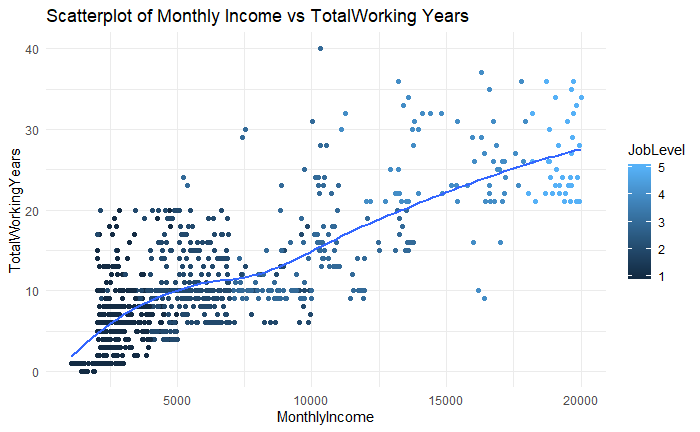

```r
gg <- ggplot(df, aes(x=exp(MonthlyIncome), y=TotalWorkingYears)) +
  geom_point(aes(col=JobLevel)) +
  geom_smooth(method="loess", se=F) +
  labs(
       y="TotalWorkingYears",
       x="MonthlyIncome",
       title="Scatterplot of Monthly Income vs TotalWorking Years")
plot(gg)
```

The scatterplot above shows a clear indicate that monthly income and Total Working years are related as well as JobLevel. Each of these are positively correlated.

```r
svr_regressor = svm(formula =MonthlyIncome ~ JobLevel+JobRole+Attrition + TotalWorkingYears_log, data=train, type = 'eps-regression')
summary(svr_regressor)
```

```
Call:
svm(formula = MonthlyIncome ~ JobLevel + JobRole + Attrition + TotalWorkingYears_log,
    data = train, type = "eps-regression")


Parameters:
   SVM-Type:  eps-regression
 SVM-Kernel:  radial
       cost:  1
      gamma:  0.08333333
    epsilon:  0.1


Number of Support Vectors:  413
```

```r
predsv <- exp(predict(svr_regressor, test))
RMSE = RMSE(predsv, exp(test$MonthlyIncome))
RMSE
```

```
[1] 1013.164
```